# Data_Mining_Clustering_Project_Tribid

# 1.4 Apply K-Means clustering on scaled data and determine optimum clusters. Apply elbow curve and silhouette score. Explain the results properly. Interpret and write inferences on the finalized clusters.

K-means clustering, Randomly we decide to give n_clusters = 3 and we look at the distribution of clusters according to the n_clusters. We apply K-means technique to the scaled data

```python
from sklearn.cluster import KMeans

k_means = KMeans(n_clusters = 3,random_state=10)
```

```python
k_means.fit(scaled_clust)
```

```
KMeans(n_clusters=3, random_state=10)
```

```python
k_means.labels_
```

```
array([1, 2, 1, 0, 1, 0, 0, 2, 1, 0, 1, 2, 0, 1, 2, 0, 2, 0, 0, 0, 0, 0,
       1, 0, 2, 1, 2, 0, 0, 0, 2, 0, 0, 2, 0, 0, 0, 0, 0, 1, 1, 2, 1, 1,
       0, 0, 2, 1, 1, 1, 0, 1, 1, 1, 1, 1, 0, 0, 0, 1, 2, 0, 0, 2, 2, 1,
       1, 2, 1, 0, 2, 0, 1, 1, 0, 1, 2, 0, 1, 2, 2, 2, 2, 1, 0, 2, 1, 2,
       1, 0, 2, 1, 2, 0, 0, 1, 1, 1, 0, 1, 2, 1, 2, 1, 2, 1, 1, 0, 0, 1,
       2, 2, 1, 0, 0, 1, 2, 2, 0, 1, 2, 0, 0, 0, 2, 2, 1, 0, 2, 2, 0, 2,
       2, 1, 0, 1, 1, 0, 1, 2, 2, 2, 0, 0, 2, 0, 1, 0, 2, 0, 2, 0, 2, 2,
       0, 2, 2, 0, 2, 1, 1, 0, 1, 1, 1, 0, 2, 2, 2, 0, 2, 0, 2, 1, 1, 1,
       2, 0, 2, 0, 2, 2, 2, 2, 1, 1, 0, 2, 2, 0, 0, 2, 0, 1, 2, 1, 1, 0,
       1, 0, 2, 1, 2, 0, 1, 2, 1, 2, 2, 2])
```

We have 3 clusters 0,1,2 To find the optimal number of clusters, we can use k-elbow method

# Calculating WSS for other values of K - Elbow Method

```python
wss =[]
```

```python
for i in range(1,11):
    KM = KMeans(n_clusters=i,random_state=1)
    KM.fit(scaled_clust)
    wss.append(KM.inertia_)
```

```python
wss
```

```
[1469.9999999999995,
 659.1717544870411,
 430.65897315130064,
 371.301721277542,
 327.9608240079031,
 290.5900305968219,
 264.83153087478144,
 240.6837259501598,
 220.85285825594738,
 206.3829103601579]
```

```python
k_means = KMeans(n_clusters = 3,random_state=1)
k_means.fit(scaled_clust)
labels = k_means.labels_
```

```python
from sklearn.metrics import silhouette_samples, silhouette_score
silhouette_score(scaled_clust,labels,random_state=1)
```

```
0.40072705527512986
```

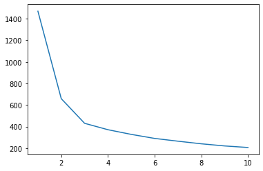

```python
plt.plot(range(1,11),wss)
```

# Observation

# 1.5 Describe cluster profiles for the clusters defined. Recommend different promotional strategies for different clusters.

Group 1: High Spending Group – Giving any reward points might increase their purchases. – Maximum max_spent_in_single_shopping is high for this group, so can be offered discount/offer on next transactions upon full payment – Increase their credit limit and – Increase spending habits – Give loan against the credit card, as they are customers with good repayment record. – Tie up with luxury brands, which will drive more one_time_maximun spending

Group 3: Medium Spending Group - They are potential target customers who are paying bills and doing purchases and maintaining comparatively good credit score. So we can increase credit limit or can lower down interest rate. - Promote premium cards/loyalty cars to increase transactions. - Increase spending habits by trying with premium ecommerce sites, travel portal, travel airlines/hotel, as this will encourage them to spend more